# Week 3: Introduction to Network Visualization

Ryan Light with significant collaboration with jimi adams

April 14, 2021

## Visualization

The ability to visualize complex information is one appealing aspect of social network analysis. It is important to consider principles of good visualization as it is easy to seduced by the value of a network visualization when it can complicate comprehension rather than facilitate it. Thankfully, there are numerous strategies for plotting networks to help tell narratives about your data.

You can accomplish a lot of these tasks in R.

Note: Katherine Ognyanova delivers the best workshops on visualization and her materials are [here](https://kateto.net/network-visualization).

Note: There are numerous network visualization packages in R, including the network package and ways of visualizing networks in the ggplot framework (see ggally and ggnet) as well as network movie packages, packages for correlational networks, bipartite networks, discpline specific networks, and other specific circumstances. We will focus primarily on igraph the most popular at this moment.

## Visualization using igraph

First, we need to load the igraph package into R.

```r
#install.packages("igraph")
library(igraph)
```

## Bringing Data Into igraph

There are many different ways to bring data into igraph. Remember that the two main ways to store network data is either an edge list (two columns: one sender, one receiver) or an adjacency matrix (i rows and j columns are the same people and the cells indicate a connection between the i row and j column). If you can make an edgelist or a matrix you can load the data into igraph.

Note: You can find a lot of cool networks through the links [here](https://dnac.ssri.duke.edu/datasets.php)

## Bringing Data Into igraph: importing csv Files

First, we can bring in the data into r using the base function read.csv(). The first example is an undirected toy network. Note that we will keep the column names as indicated by “header=T”

```r
toy.undirected <- read.csv("data/simple_undirected.csv", header=T)   # reading in the undirected mixing example

print(toy.undirected)
```

```
##   id alt1 alt2 alt3 attr1
## 1  1    3   NA   NA     1
## 2  2    3   NA   NA     1
## 3  3    1    2    4     1
## 4  4    3    5    6     0
## 5  5    4    6   NA     0
## 6  6    4    5   NA     0
```

Now we need to clean the data up a bit to make an edge list. If we look above, we can see another way of storing network data - the adjacency list. Adjacency lists consist of nodes and the alters that are adjacent to them. So person 6 is connected to alters 4 and 5. We first separate the adjacency list and the nodal attribute. We can use the row() function to transform the adjacency list into a edge list.

```r
ties<- subset(toy.undirected,select=c(alt1,alt2,alt3))  # stripping off just the adjacency list
nodes <- subset(toy.undirected,select=c(id,attr1))      # stripping off just the attributes
toy.df <- data.frame(snd = row(ties)[!is.na(ties)], rcv = ties[!is.na(ties)])
```

Igraph requires that we make an igraph object and there are several ways of doing so. In this example, we use graph.data.frame() to make this object. We indicate that the network is undirected and point igraph to the nodes data frame for information on nodal attributes.

```r
toy.g <- graph.data.frame(toy.df, directed=F, vertices=nodes)   # converting to an igraph “graph” object
```

We can use plot.igraph() function to visualize the graph. We use the attribute that was introduced from nodes to color the nodes (Be sure it’s the same, *2 is to avoid using the same color for the label/node color).

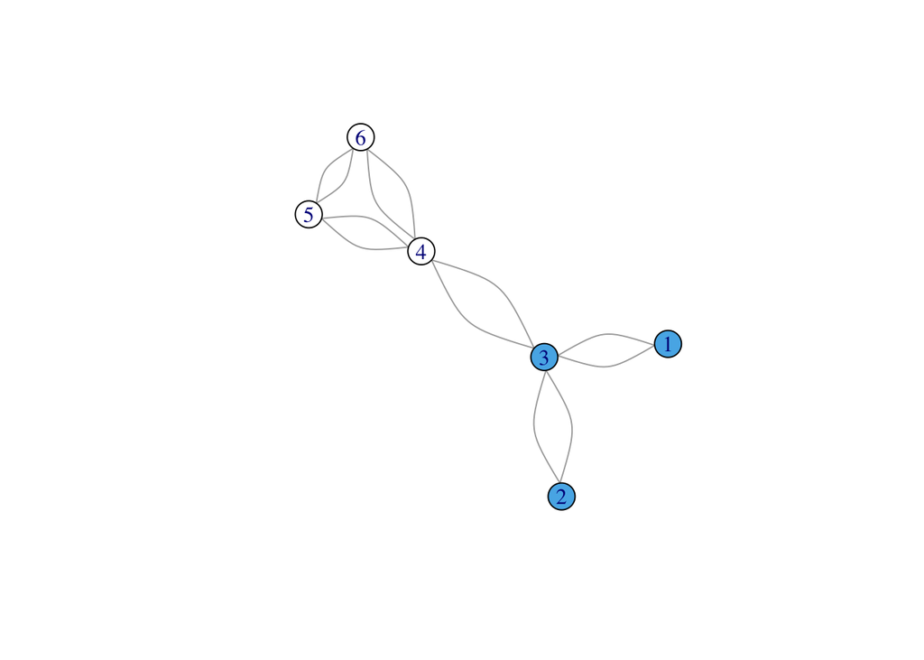

```r
plot.igraph(toy.g, vertex.color=V(toy.g)$attr1*2)
```

The above toy graph consisted of undirected ties. Some graphs have directed ties. Let’s check out how igraph plots these.

Note we can also use the graph_from_adj_list function to bring adjacency lists into igraph. If you want an undirected graph, then mode=“all”. And if you want a directed graph of sent ties, then mode=“out”.

```r
toy.directed <- read.csv("data/simple_directed.csv", header=T)
nodes <- subset(toy.directed,select=c(id,attr1))
ties <- subset(toy.directed,select=c(alt1,alt2,alt3))

ties[is.na(ties)] <- 0

toy.g.directed <- graph_from_adj_list(ties+1, mode="out")
```

You can store node or vertex attributes using V(g)$attribute <- Attribute as follows (make sure the order is the same)

```r
V(toy.g.directed)$attribute <- nodes$attr1
```

And plot the directed graph.

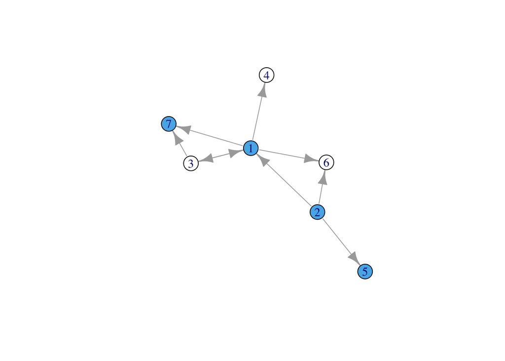

```r
plot.igraph(simplify(toy.g.directed), vertex.color=V(toy.g.directed)$attribute*2)
```

```r
V(toy.g.directed)         # lists the specified vertices
```

```
## + 7/7 vertices, from bb959af:
## [1] 1 2 3 4 5 6 7
```

```r
E(toy.g.directed)                   # gives the edgelist of the specified graph
```

```
## + 18/18 edges from bb959af:
##  [1] 1->4 1->3 1->4 1->7 1->6 1->1 2->1 2->1 2->5 2->6 2->1 2->1 3->1 3->1 3->1
## [16] 3->7 3->1 3->1
```

Note that the simplify function removes any loops or multiple edges.

##Bringing Data into igraph: edge lists

You can also write edge lists directly into igraph. Igraph will read each pair as an edge. Here we have indicated an undirected graph by directed=F.

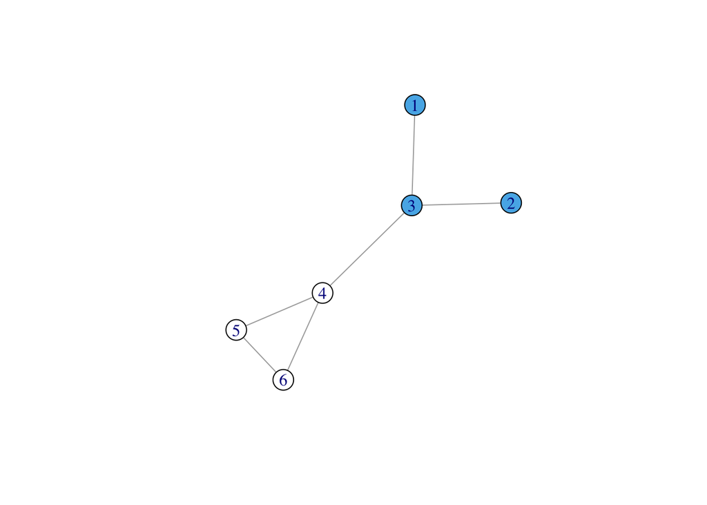

```r
edge.list <- c(1,3, 2,3, 3,4, 4,5, 4,6, 5,6)

exa_g <- graph(edge.list, directed=F)
V(exa_g)$attr1 <- c(1,1,1,0,0,0)        # attach the attribute vector
plot.igraph(exa_g, vertex.color=V(exa_g)$attr1*2)   # how’s it look?
```

We can also add multiple kinds of edges (and other attributers) in the same way as node attributes, but calling edges instead of vertices E(g)$attribute <- Attribute. Like this:

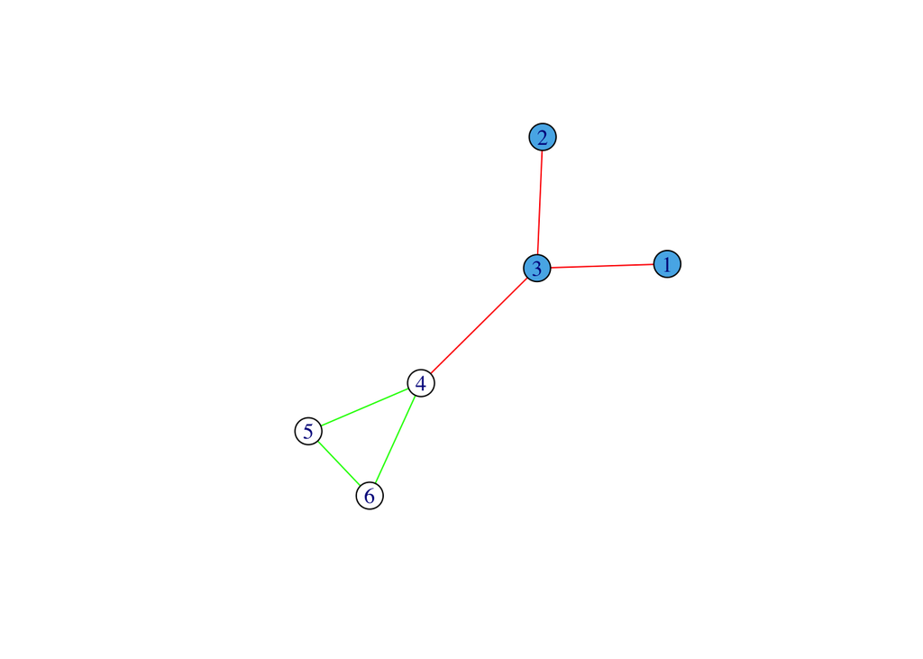

```r
E(exa_g)$type <- c("friend", "friend" , "friend", "family", "family", "family")     # attach the multiplex vector

plot.igraph(exa_g, vertex.color=V(exa_g)$attr1*2, edge.color=c("red","green")[(E(exa_g)$type=="family")+1]) # how’s it look?
```

## Bringing data in igraph using read.graph

We can bring data into igraph via other programs like the networks program Pajek. Pajek is a popular program used to visualize and analyze social networks. The file extensions for Pajek include .net for the network file and .clu for attributes which are often kept in separate files.

read.graph() function will read networks from other programs. format= identifies the type of file (e.g. the program in which the file was generated)

This Valente data captures the friendship ties in a fifth grade classroom.

```r
valente <- read.graph("data/valente.net", format="pajek")

class(valente)
```

```
## [1] "igraph"
```

## Quick look at igraph info

“The first line always starts with IGRAPH, showing you that the object is an igraph graph. Then a four letter long code string is printed. The first letter distinguishes between directed (‘D’) and undirected (‘U’) graphs. The second letter is ‘N’ for named graphs, i.e. graphs with the name vertex attribute set. The third letter is ‘W’ for weighted graphs, i.e. graphs with the weight edge attribute set. The fourth letter is ‘B’ for bipartite graphs, i.e. for graphs with the type vertex attribute set.” (http://igraph.org/r/doc/print.igraph.html)

```r
print(valente)
```

```
## IGRAPH 6ae6f3b DN-- 37 145 --
## + attr: id (v/c), name (v/c)
## + edges from 6ae6f3b (vertex names):
##  [1] 34->13 34->7  34->11 6 ->34 6 ->13 6 ->11 6 ->9  9 ->7  9 ->11 9 ->13
## [11] 9 ->34 9 ->6  11->9  11->6  11->13 11->34 13->34 13->6  13->7  7 ->1
## [21] 7 ->8  1 ->7  1 ->8  27->7  27->29 27->19 27->4  27->13 8 ->1  8 ->32
## [31] 8 ->21 8 ->17 18->7  18->1  18->4  18->17 2 ->32 2 ->7  2 ->21 2 ->30
## [41] 2 ->37 4 ->27 4 ->21 4 ->7  4 ->19 4 ->18 32->8  32->30 21->27 21->30
## [51] 21->19 19->33 19->32 19->30 19->21 33->17 33->4  33->21 33->30 17->32
## [61] 17->33 17->8  17->21 17->4  17->30 17->19 30->21 30->33 30->17 30->32
## [71] 23->26 23->27 23->18 35->23 35->17 35->2  35->20 20->3  20->30 20->17
## + ... omitted several edges
```

## Reading Attributes

Next, we bring the gender attribute (valente.clu) file from pajek into R. We skip the first line (skip=1) because pajek files include one additional line that is not needed.

We store attributes as follows: V(g)$attribute

```r
gender <- as.matrix(read.table("data/valente.clu", skip=1))

# attaching the attribute, make numeric
V(valente)$gender <- as.vector(gender)
```

## Initial Plot

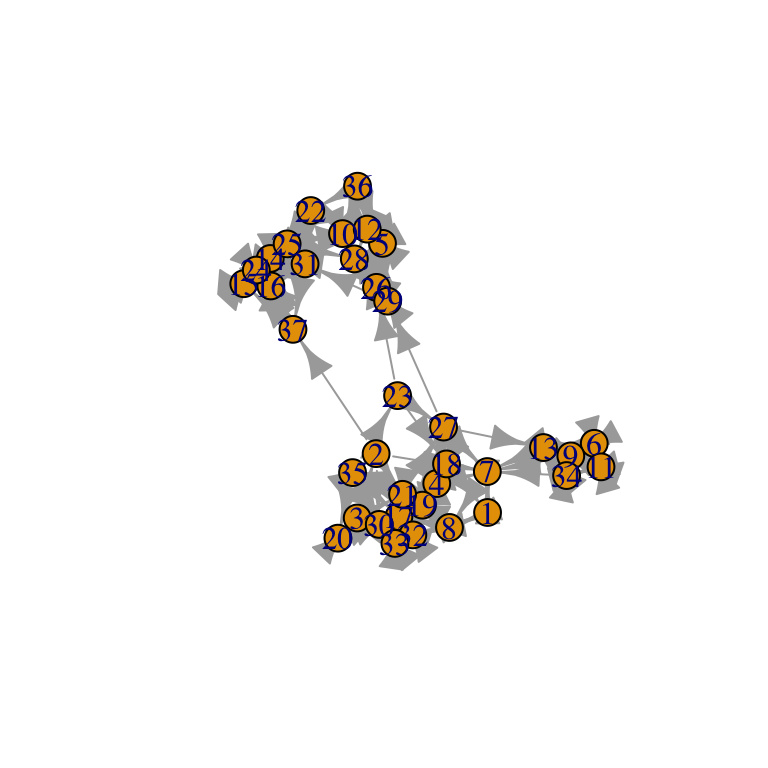

```r
plot.igraph(valente)
```

## Adding an attribute to the graph

We can add attributes to the graph in several ways. The first and most obvious way is to identify differences in a nominal attribute by different colored nodes.

This assigns attribute-based colors to nodes: vertex.color=V(g)$attribute

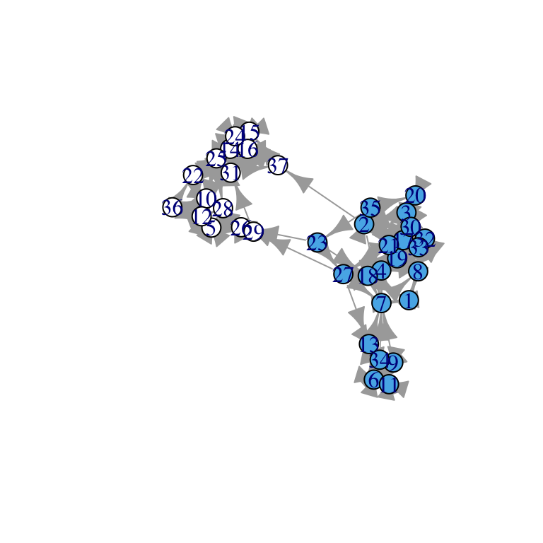

```r
plot.igraph(valente, vertex.color=V(valente)$gender*2)
```

## Specifying colors of an attribute

We likely want to control the colors that we are using in our plots. There are several ways to do that. For example, we can set the colors of the attributes that interest us.

Note that in the previous graph we multiplied the attribute by 2 (vertex.color=V(valente)$gender*2) to avoid having the same color for the label/node color

```r
attr.colors <- c("tomato", "gold")

V(valente)$gender <- V(valente)$gender+1

V(valente)$colors <- attr.colors[V(valente)$gender]
```

## Specifying colors of an attribute

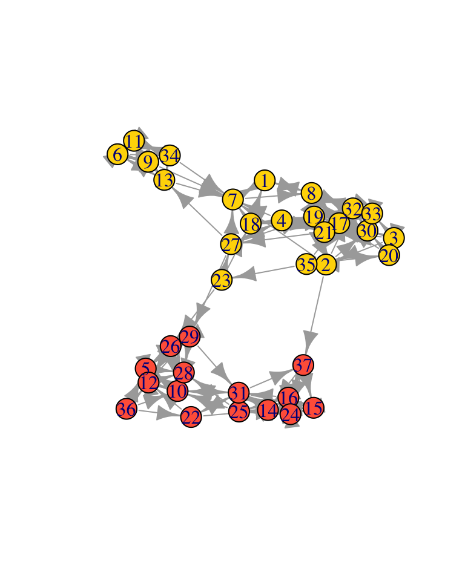

## Specifying colors of a graph

If you don’t have an attribute of interest you can set vertex.color in the same way you did above, but with an color instead of an attribute.

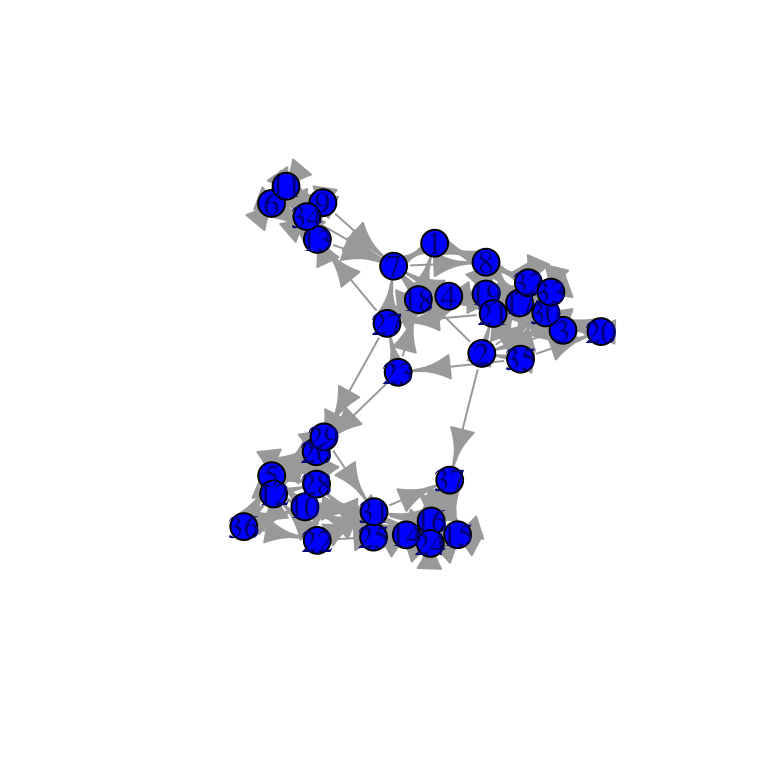

```r
plot.igraph(valente, vertex.color="blue")
```

## Node size

We can also use nodal size to convey something about the magnitude of a particular actor. Here we make a vertex attribute for degree (the total number of edges connected to a node) and then set the vertex size.

vertex.size=V(graph)$attribute

```r
V(valente)$node.size <- degree(valente)

plot.igraph(valente, vertex.color=V(valente)$colors,
            vertex.size=V(valente)$node.size)
```

## Node size

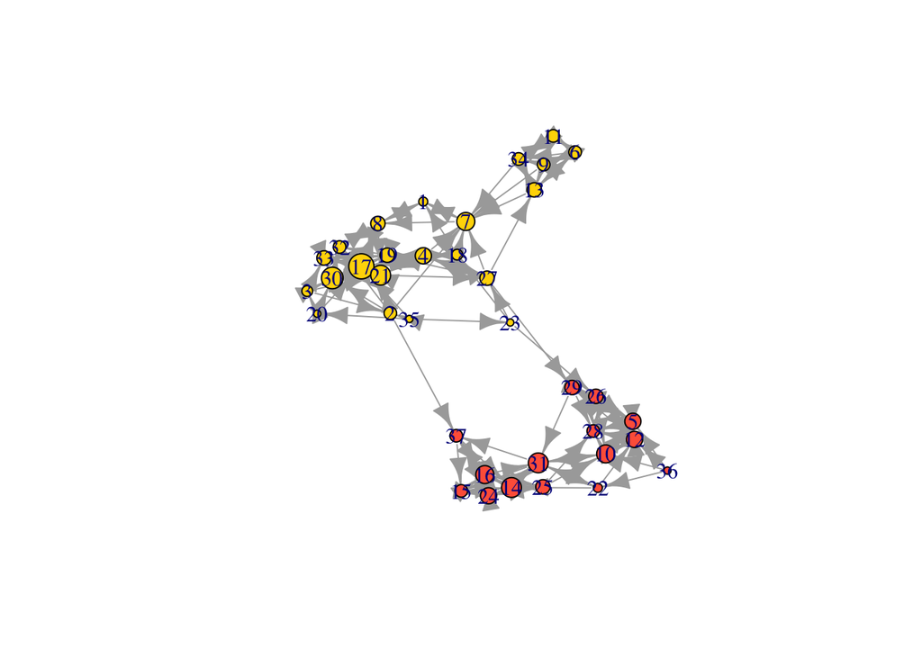

## Node size

We can can adjust this a bit by adding a multiplier. We can also change the shape of the node.

vertex.size=V(valente)$node.size*2

vertex.shape=c(“circle”, “square”, “csquare”, “rectangle”, “crectangle”, “vrectangle”, “none”)

```r
V(valente)$node.size <- degree(valente)

plot.igraph(valente, vertex.color=V(valente)$colors,
            vertex.size=V(valente)$node.size*2, vertex.shape="square")
```

## Node size

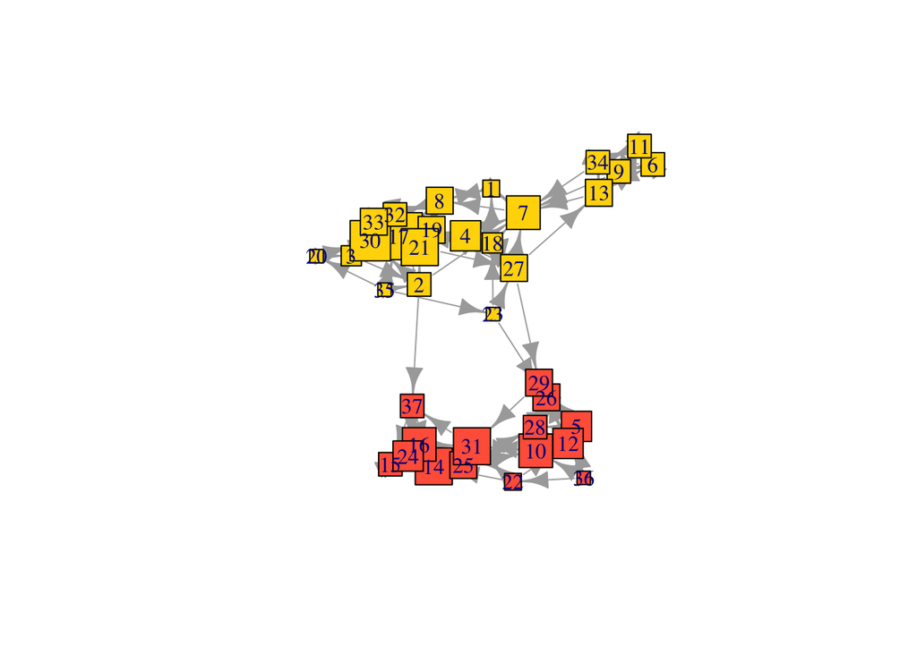

## Visualizing edges

The most annoying default for R is the arrow size in directed graphs. You can change that with edge.arrow.size=.5

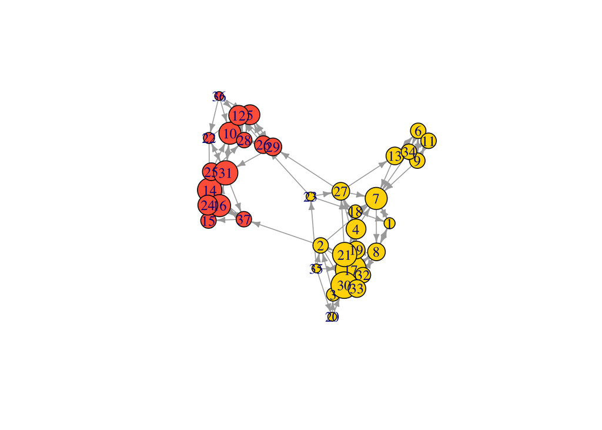

```r
plot.igraph(valente, vertex.color=V(valente)$colors,
            vertex.size=V(valente)$node.size*2, edge.arrow.size=.5)
```

## Visualizing Edges

We can control the width and/or gray scale of edges to convey tie strength or some other characteristic using

edge.width=E(g)$attribute

```r
counts <- seq(from=1, to=10, by=1)
wghts <- sample(counts, size=145, replace=TRUE)

E(valente)$weight <- wghts

plot.igraph(valente, vertex.color=V(valente)$colors, edge.arrow.size=.5,
            edge.width=E(valente)$weight)
```

## Visualizing Edges

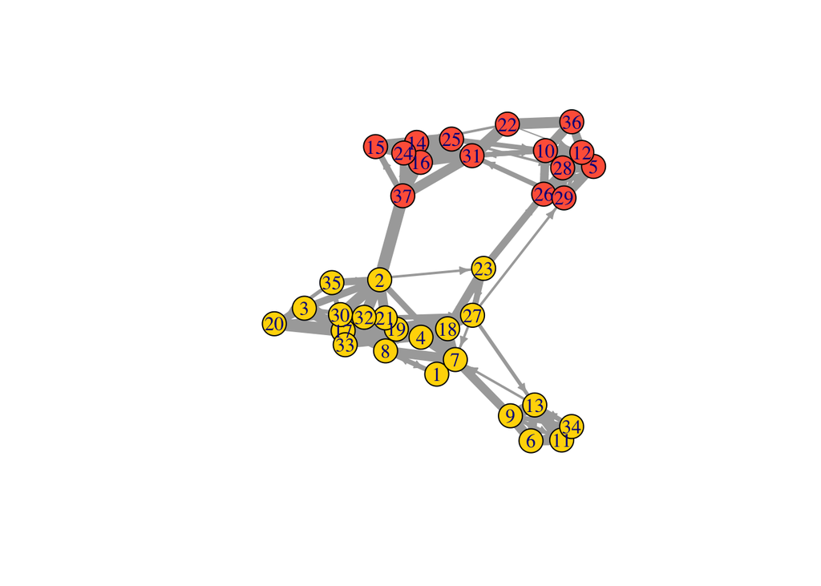

## Visualizing Edges

Again, we might want to include a multiplier if the edges are too big.

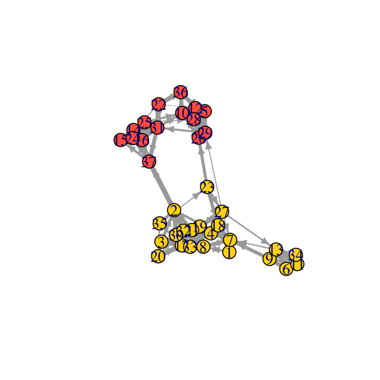

```r
plot.igraph(valente, vertex.color=V(valente)$colors, edge.arrow.size=.5,
            edge.width=E(valente)$weight/2)
```

## Layouts

One of the most important decisions that we make regards the graph layout. Igrpah includes numerous layout options. Which you can find [here](http://igraph.org/r/doc/layout_.html)

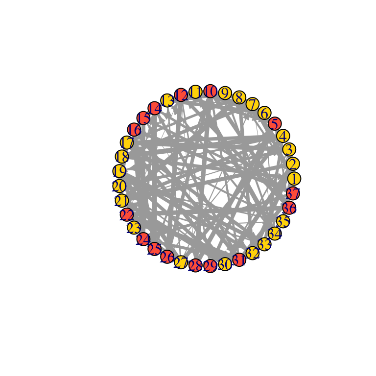

```r
plot.igraph(valente, vertex.color=V(valente)$colors, edge.arrow.size=.5,
            edge.width=E(valente)$weight/2, layout=layout_in_circle)
```

## Layouts

Fruchterman-Reingold - Force Directed

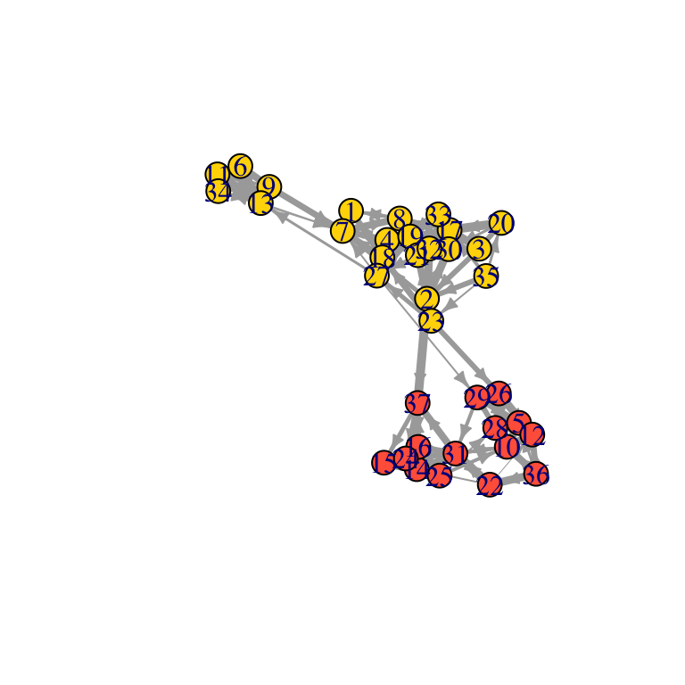

```r
plot.igraph(valente, vertex.color=V(valente)$colors, edge.arrow.size=.5,
            edge.width=E(valente)$weight/2, layout=layout_with_fr)
```

## Grid Layout

Grid Layout - Make a grid

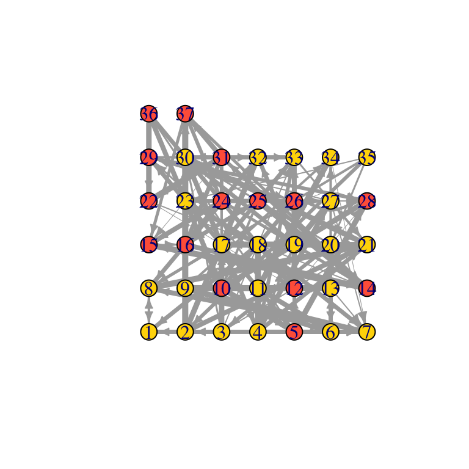

```r
plot.igraph(valente, vertex.color=V(valente)$colors, edge.arrow.size=.5,
            edge.width=E(valente)$weight/2, layout=layout.grid)
```

## Layouts

Kamada-Kawai: Spring Embedder Layout

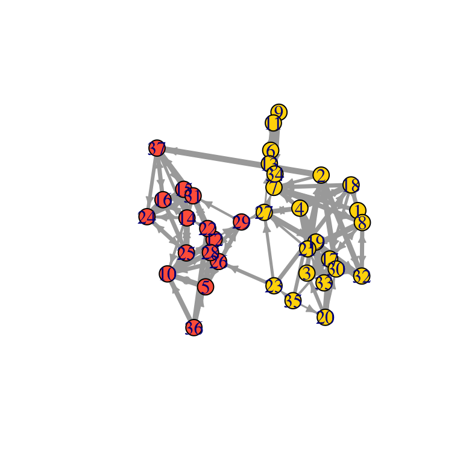

```r
plot.igraph(valente, vertex.color=V(valente)$colors, edge.arrow.size=.5,
            edge.width=E(valente)$weight/2, layout=layout_with_kk)
```

## Layouts

MDS Layout

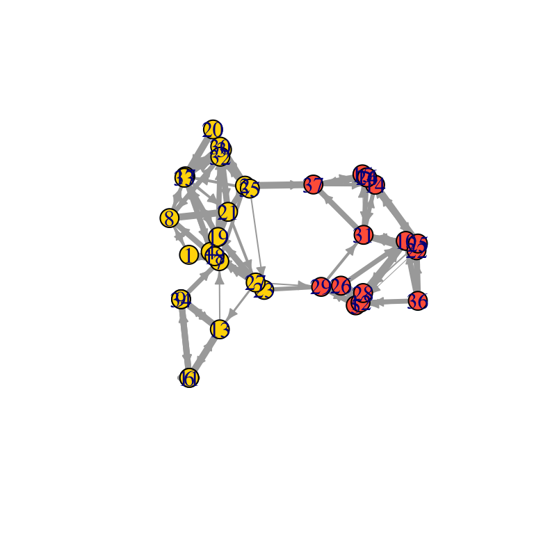

```r
plot.igraph(valente, vertex.color=V(valente)$colors, edge.arrow.size=.5,
            edge.width=E(valente)$weight/2, layout=layout.mds)
```

## Bringing Data into igraph: two-mode data

In a few weeks we will talk about duality and two-mode networks. Here is a quick example of how we might bring a two-mode network into igraph.

I’ve collected data on Star Wars movies from imdb.com. I copied and pasted the top 15 actors in each of the first six movies into excel and saved as a csv.

```r
star.wars <- read.csv("data/star_wars.csv" , header=TRUE)

sw.g <- graph.data.frame(star.wars)

print(sw.g)
```

```
## IGRAPH 330222d DN-- 56 90 --
## + attr: name (v/c)
## + edges from 330222d (vertex names):
##  [1] Liam Neeson       ->Episode 1: The Phantom Menace
##  [2] Ewan McGregor     ->Episode 1: The Phantom Menace
##  [3] Natalie Portman   ->Episode 1: The Phantom Menace
##  [4] Jake Lloyd        ->Episode 1: The Phantom Menace
##  [5] Ian McDiarmid     ->Episode 1: The Phantom Menace
##  [6] Pernilla August   ->Episode 1: The Phantom Menace
##  [7] Oliver Ford Davies->Episode 1: The Phantom Menace
##  [8] Hugh Quarshie     ->Episode 1: The Phantom Menace
## + ... omitted several edges
```

```r
bipartite.mapping(sw.g)
```

```
## $res
## [1] TRUE
##
## $type
##  [1] FALSE FALSE FALSE FALSE FALSE FALSE FALSE FALSE FALSE FALSE FALSE FALSE
## [13] FALSE FALSE FALSE FALSE FALSE FALSE FALSE FALSE FALSE FALSE FALSE FALSE
## [25] FALSE FALSE FALSE FALSE FALSE FALSE FALSE FALSE FALSE FALSE FALSE FALSE
## [37] FALSE FALSE FALSE FALSE FALSE FALSE FALSE FALSE FALSE FALSE FALSE FALSE
## [49] FALSE FALSE  TRUE  TRUE  TRUE  TRUE  TRUE  TRUE
```

```r
V(sw.g)$type <- bipartite.mapping(sw.g)$type
```

## Bringing Data into igraph: two-mode data

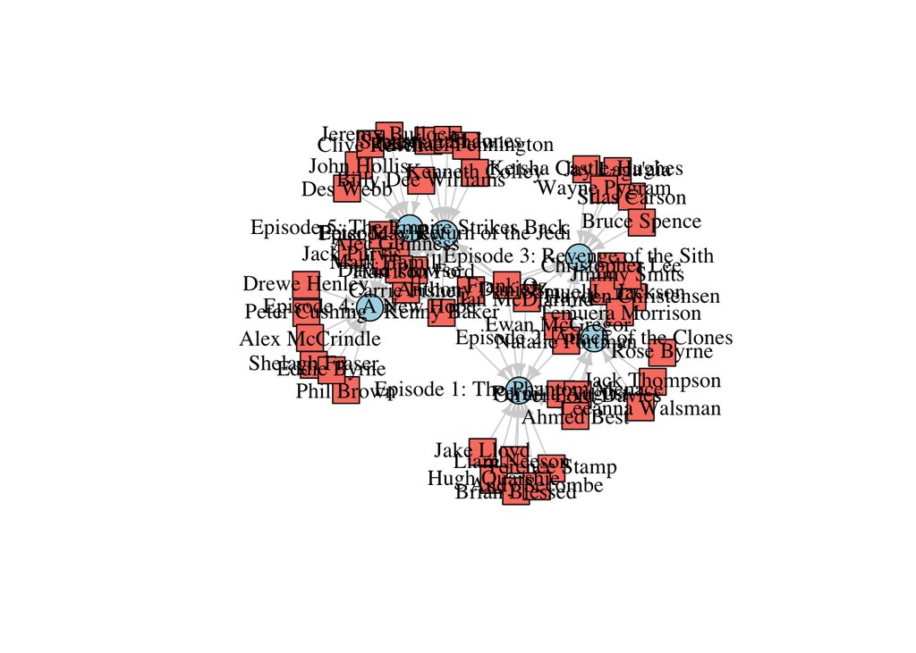

```r
V(sw.g)$color <- ifelse(V(sw.g)$type, "lightblue", "salmon")
V(sw.g)$shape <- ifelse(V(sw.g)$type, "circle", "square")
E(sw.g)$color <- "lightgray"

plot.igraph(sw.g, layout=layout.fruchterman.reingold, vertex.label.color="black", edge.arrow.size=.5)
```

## Bringing Data into igraph: two-mode data

```r
library(networkD3)
sw.d3 <- igraph_to_networkD3(sw.g)

simpleNetwork(sw.d3$links)
```

[interactive chart not shown]

## Bringing Data into igraph: two-mode data

[interactive chart not shown]

## Many other graph options

- For additional examples see (http://kateto.net/networks-r-igraph)
- Animations of dynamic networks (networkDynamic package)
- More on Interactive networks
- Communities
- More on Bipartitie networks
- Summarize big data